# Modul 3: Visualisasi Data

Big Data and Business Analytics Laboratory, SBM-ITB

Visualisasi Data didefinisikan sebagai teknik untuk mempresentasikan data dalam bentuk grafik atau bagan untuk menampilkan informasi yang tersembunyi dalam data agar lebih mudah dipahami oleh pembaca / pengguna laporan.

Di modul kali in kita akan belajar melakukan visualisasi data menggunakan R. Dataset yang akan kita gunakan masih sama seperti data pada modul sebelumnya yaitu Bank Marketing dataset.

## Import Data

Sebelum melakukan visualisasi data, kita harus mengimport dataset terlebih dahulu.

```r
# Load Package readr
library(readr)

# Import data bank-marketing.csv dari direktori data/raw
df <- read_csv2("data/raw/bank-marketing.csv")
```

```
## ℹ Using ',' as decimal and '.' as grouping mark. Use `read_delim()` for more control.
```

Kita kemudian dapat melihat rangkuman dataset tersebut menggunakan fungsi glimpse dari Package `dplyr` yang telah kita pelajari di modul sebelumnya.

```r
# Load package readr
library(dplyr)
# Melihat rangkuman data
glimpse(df)
```

```
## Rows: 45,211
## Columns: 17
## $ age       <dbl> 58, 44, 33, 47, 33, 35, 28, 42, 58, 43, 41, 29, 53, 58, 57,…
## $ job       <chr> "management", "technician", "entrepreneur", "blue-collar", …
## $ marital   <chr> "married", "single", "married", "married", "single", "marri…
## $ education <chr> "tertiary", "secondary", "secondary", "unknown", "unknown",…
## $ default   <chr> "no", "no", "no", "no", "no", "no", "no", "yes", "no", "no"…
## $ balance   <dbl> 2143, 29, 2, 1506, 1, 231, 447, 2, 121, 593, 270, 390, 6, 7…
## $ housing   <chr> "yes", "yes", "yes", "yes", "no", "yes", "yes", "yes", "yes…
## $ loan      <chr> "no", "no", "yes", "no", "no", "no", "yes", "no", "no", "no…
## $ contact   <chr> "unknown", "unknown", "unknown", "unknown", "unknown", "unk…
## $ day       <dbl> 5, 5, 5, 5, 5, 5, 5, 5, 5, 5, 5, 5, 5, 5, 5, 5, 5, 5, 5, 5,…
## $ month     <chr> "may", "may", "may", "may", "may", "may", "may", "may", "ma…
## $ duration  <dbl> 261, 151, 76, 92, 198, 139, 217, 380, 50, 55, 222, 137, 517…
## $ campaign  <dbl> 1, 1, 1, 1, 1, 1, 1, 1, 1, 1, 1, 1, 1, 1, 1, 1, 1, 1, 1, 1,…
## $ pdays     <dbl> -1, -1, -1, -1, -1, -1, -1, -1, -1, -1, -1, -1, -1, -1, -1,…
## $ previous  <dbl> 0, 0, 0, 0, 0, 0, 0, 0, 0, 0, 0, 0, 0, 0, 0, 0, 0, 0, 0, 0,…
## $ poutcome  <chr> "unknown", "unknown", "unknown", "unknown", "unknown", "unk…
## $ y         <chr> "no", "no", "no", "no", "no", "no", "no", "no", "no", "no",…
```

## Visualisasi data menggunakan base R

Pada dasarnya, dengan R kita dapat melakukan visualiasi tanpa Package apapun.

### Histogram

Kita dapat melakukan visualisasi histogram untuk melihat distribusi umur nasabah dengan funsi hist()

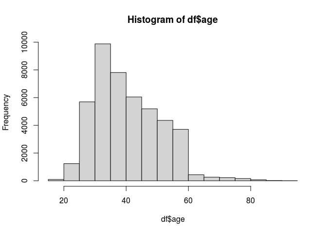

```r
# Visualisasi Histogram
hist(df$age)
```

Sayangnya, visualisasi dengan menggunakan base R sangat terbatas. Hasil visualisasinya juga kurang menarik. Dengan demikian, biasanya kita menggunakan Package visualisasi data yang sangat mumpuni yaitu `ggplot2`.

## Visualisasi data menggunakan ggplot2

ggplot2 merupakan Package untuk visualisasi data yang juga diciptakan oleh Hadley Wickham. `ggplot2` memiliki kelebihan dalam pembuatan grafik visualisasi data. Grafik yang diproduksi dapat lebih elegan dan kompleks. Untuk menggunakan package ini, kita harus menginstall dan memuat Package `ggplot2` kedalam R environtment kita.

```r
# Install Package
install.packages("ggplot2")
# Load Package
library(ggplot2)
```

### Histogram

Kita akan mencoba untuk melakukan visualisasi histogram dengan variable yang sama menggunakan `ggplot2`

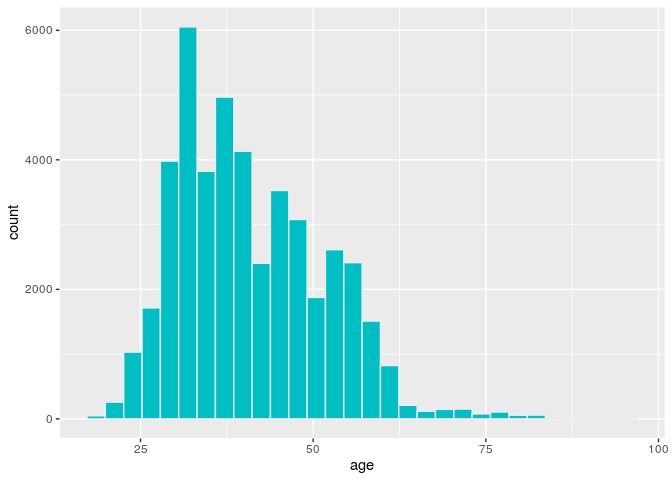

```r
# Histogram Age
ggplot(data = df, aes(x = age)) +
  geom_histogram(colour = "#e9ecef", fill = "#00bfc4")
```

Jauh lebih menarik bukan? Selain histogram, masik banyak grafik visualisasi lainnya yang dapat diproduksi menggunakan package `ggplot2`. Berikut beberapa contohnya.

### Barchart

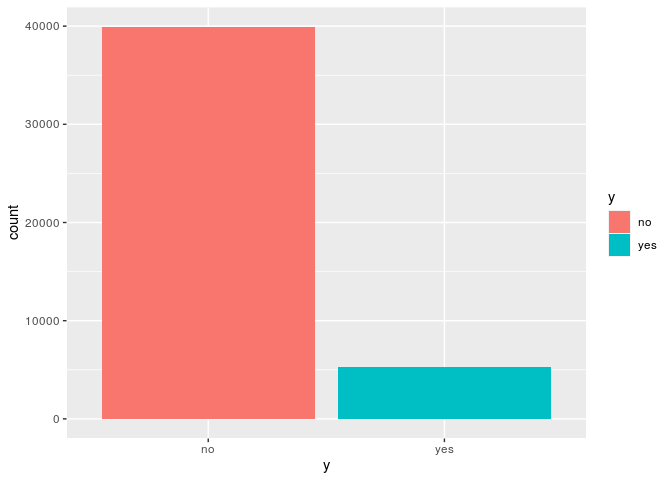

```r
# Bar Chart
ggplot(data = df, aes(x = y, fill = y)) +
  geom_bar()
```

### Scatter Plot

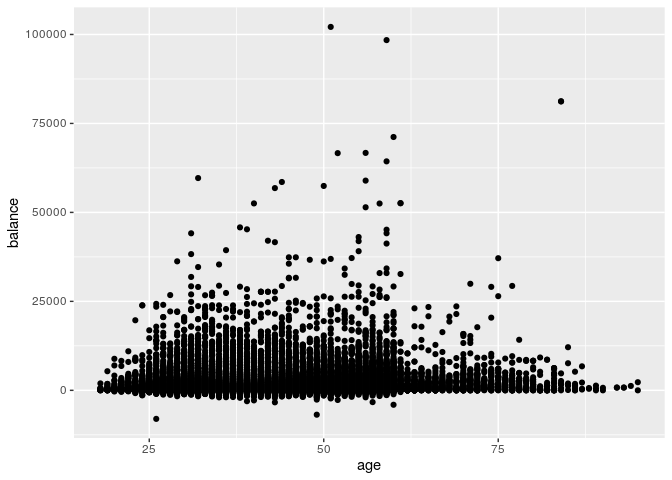

```r
# Scatter Plot
ggplot(data = df, aes(x = age, y = balance)) +
  geom_point()
```

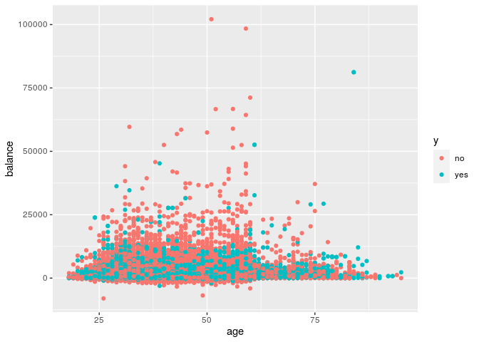

```r
# Scatter Plot 2
ggplot(data = df, aes(x = age, y = balance, colour = y, fill = y)) +
  geom_point()
```

### Line Plot

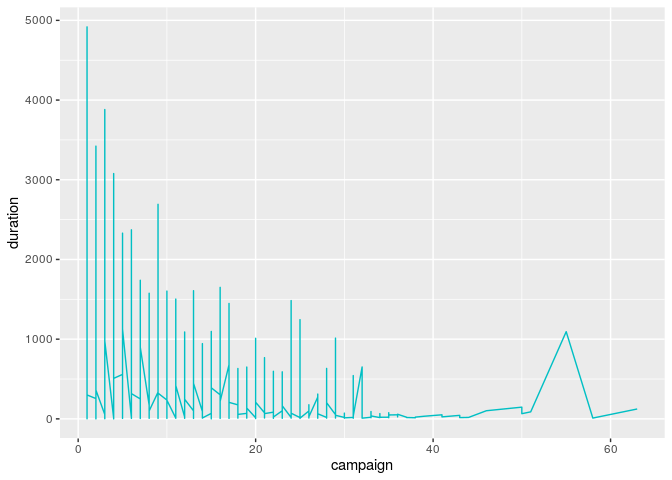

```r
# line plot
ggplot(data = df, aes(x = campaign, y = duration)) +
  geom_line(colour = "#00bfc4")
```

### Box Plot

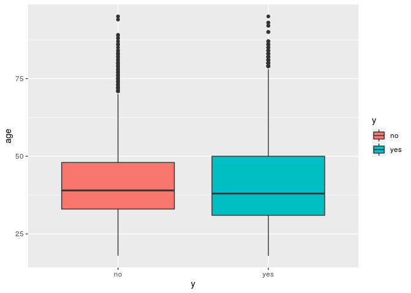

```r
# Box Plot
ggplot(data = df, aes(x = y, y = age, fill = y)) +
  geom_boxplot()
```

## Kustomisasi Graph

Graph yang dihasilkan melalui ggplot juga dapat dikustomisasi sehingga lebih menarik dan informatif. Berikut ini beberapa contoh kustomisasi yang dapat kita lakukan. Untuk kustomisasi secara lengkap teman-teman melihat dokumentasi ggplot2.

### Judul dan sub judul

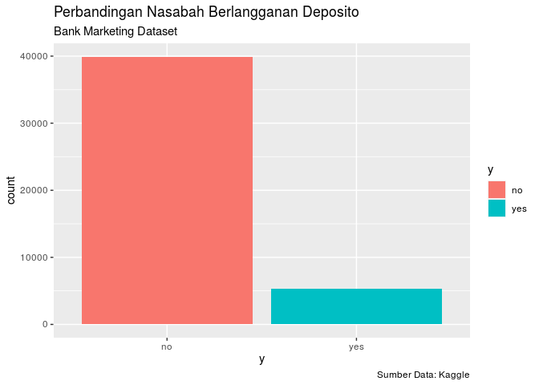

```r
# Bar Chart
ggplot(data = df, aes(x = y, fill = y)) +
  geom_bar() +
  labs(
    title = "Perbandingan Nasabah Berlangganan Deposito",
    subtitle = "Bank Marketing Dataset",
    caption = "Sumber Data: Kaggle"
  )
```

### Mengganti Label X dan Y

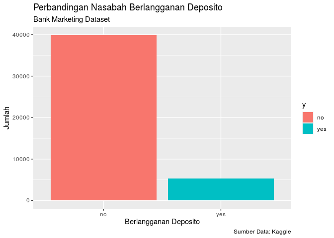

```r
# Bar Chart
ggplot(data = df, aes(x = y, fill = y)) +
  geom_bar() +
  labs(
    title = "Perbandingan Nasabah Berlangganan Deposito",
    subtitle = "Bank Marketing Dataset",
    caption = "Sumber Data: Kaggle"
  ) +
  xlab("Berlangganan Deposito") +
  ylab("Jumlah")
```

### Mengganti Posisi Legenda

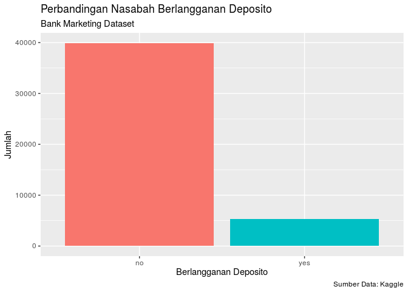

```r
# Bar Chart
ggplot(data = df, aes(x = y, fill = y)) +
  geom_bar() +
  labs(
    title = "Perbandingan Nasabah Berlangganan Deposito",
    subtitle = "Bank Marketing Dataset",
    caption = "Sumber Data: Kaggle"
  ) +
  xlab("Berlangganan Deposito") +
  ylab("Jumlah") +
  theme(legend.position = "none")
```

### Mengganti Tema

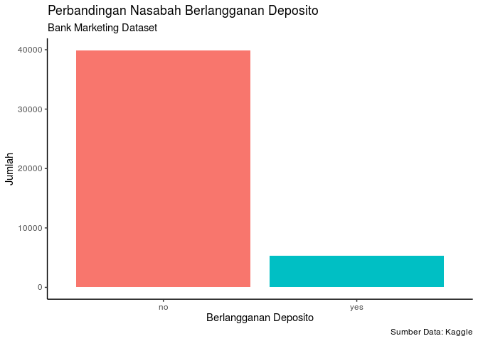

```r
# Bar Chart
ggplot(data = df, aes(x = y, fill = y)) +
  geom_bar() +
  theme_classic() +
  labs(
    title = "Perbandingan Nasabah Berlangganan Deposito",
    subtitle = "Bank Marketing Dataset",
    caption = "Sumber Data: Kaggle"
  ) +
  xlab("Berlangganan Deposito") +
  ylab("Jumlah") +
  theme(legend.position = "none")
```

### Membuat Interaktif dengan Plotly

```r
# Load package Plotly
library(plotly)
```

```r
# Chart interaktif
line_chart <- ggplot(data = df, aes(x = duration, y = balance)) +
  geom_line(colour = "#00bfc4")

ggplotly(line_chart)
```

[output not shown]

## Praktek

Sekarang teman-teman sudah paham teknik-teknik melakukan visualisasi data menggunakan Package `ggplo2`. Sama seperti sebelumnya, saatnya kita meangaplikasikan ke kasus baru. Kita akan menggunakan dataset telco customer churn dataset sama seperti modul sebelumnya.

```r
# Import dataset Telco Customer Churn
df_churn <- read_csv("data/raw/customer-churn.csv")
```

### Soal

Sama seperti praktik sebelumnya, teman-teman masih berperan sebagai seorang data scientist di perusahaan telekomunikasi. Teman-teman diminta untuk menjawab pertanyaan yang ajukan oleh manajemen. Pertanyaan kali ini terkait dengan tugas visualisasi data menggunakan Package `ggplot`.

### Contoh Soal: Visualisasikan banyaknya pelanggan yang churn dan tidak

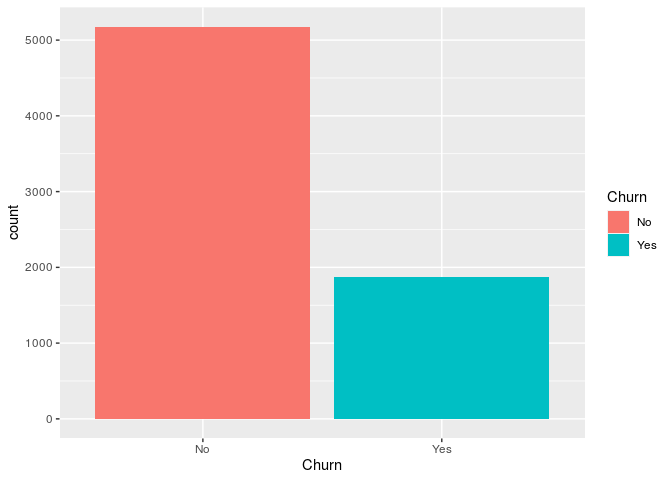

```r
# Jawaban
ggplot(data = df_churn, aes(x = Churn, fill = Churn)) +
  geom_bar()
```

#### Soal 1: Visualisasikan jumlah pelanggan pada masing-masing tipe kontrak

```r
# Jawaban soal 1
```

#### Soal 2: Visualisasikan jumlah pelanggan berjenis kelamin laki-laki dan perempuan

```r
# Jawaban soal 2
```

#### Soal 3: Visualisasikan hubungan tenure dan jumlah tagihan bulanan, kemudian lihat keterkaitannya dengan keputusan churn (churn atau tidak churn)

```r
# Jawaban soal 3
```

#### Soal 4: Visualisasikan jumlah pelanggan laki-laki dan perempuan yang churn

```r
# Jawaban soal 4
```

#### Soal 5: Visualisasikan Secara interaktif proporsi pelanggan partner yang churn dan tidak

Petunjuk: Menggunakan ggplotly

```r
# Jawaban soal 5
```